# 6 Putting it together

## 6.1 Supplementary results

### 6.1.1 Varying fixed-lag resampling $L$

Fixed-lag resampling introduces a potential source of bias. Fundamentally, we are approximating the smoothing posterior $P(X_t|y_{1:T})$ with $P(X_t|y_{1:t+L})$, ignoring any direct association between the current hidden state $X_t$ and data collected more than $L$ steps in the future. This can be an issue if the process does not “forget” fast enough (for example, if $R_t$ varies very slowly over time), or if $L$ is smaller than the maximum[^1] generation time.

Compared to hidden-state estimation, the choice of $L$ is generally less important when estimating fixed parameters using PMMH, as only the filtering distribution $P(X_t|y_{1:t})$ is required for this task. In the Markovian setting, all past-state resampling could be disabled entirely, but as the renewal model is inherently non-Markovian, past-state resampling is required. However, particle degeneracy is not a concern, so $L$ could be set to $t$ (full past-state resampling), but this is computationally expensive. Using fixed-lag resampling thus strikes a balance between these two extremes, provided $L$ is large enough that hidden-state trajectories are consistent over the maximum generation time.

To test the effect of varying $L$, we fit the third example model from Section 8.3, with $L = 5, 10, 20, 40, 80$. For context, the mean generation time is assumed to be 6.5 days, with $L = 20$ covering 98.8% of the probability mass of the generation time distribution. The similarity of posterior means and 95% credible intervals of the parameters $\sigma$ and $\phi$ suggest there is little systematic impact of $L$ (the variation observed arises from Monte Carlo error) on parameter estimation in this example. Greater variation is seen in estimates of the reproduction number at low $t$, where there is limited data. Despite this, there is a high level of agreement between estimates for later estimates, despite the known problems with using $L < 20$.

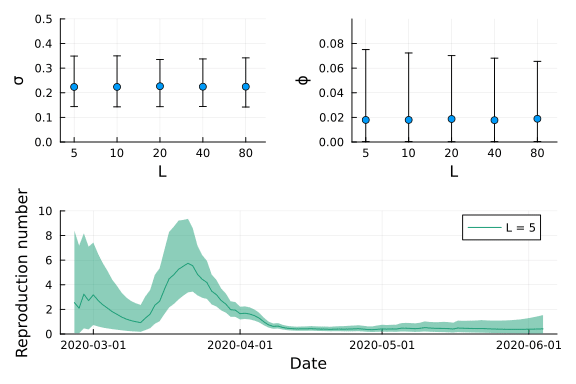

```julia
using Plots; gr()
using Measures, CSV, DataFrames


include("../src/LoadData.jl")
include("../src/PMMH.jl")
include("../src/FitModel.jl")
include("../src/MarginalPosterior.jl")
include("../src/Support.jl")

Y = loadData("NZCOVID")

function ExampleModel3(θ, Y::DataFrame, opts::Dict)

    # Extract frequently used options
    T = opts["T"] # Number of time steps
    N = opts["N"] # Number of particles to use
    L = opts["L"] # Length of fixed-lag resampling

    # Define the serial interval
    ω = pdf.(Gamma(2.36, 2.74), 1:100) # (Unnormalised) serial interval
    ω = ω/sum(ω) # Normalise the serial interval

    # Initialise output matrices
    R = zeros(N, T) # Matrix to store particle values
    I = zeros(N, T) # Local infections
    W = zeros(N, T) # Matrix to store model weights

    # Sample from initial distribution
    R[:,1] = rand(Uniform(0, 10), N)
    I[:,1] = rand.(opts["pI0"], N)

    # Run the filter
    for tt = 2:T

        # Project according to the state-space model
        R[:,tt] = exp.(rand.(Normal.(log.(R[:,tt-1]), θ[1])))

        # Calculate force-of-infection and sample infections
        Λ = sum(I[:,tt-1:-1:1]  .* opts["ω"][1:tt-1]', dims=2)
        I[:,tt] = rand.(Poisson.(R[:,tt] .* Λ))

        # Weight according to the observation model
        r = 1/θ[2]
        p = 1 ./ (1 .+ θ[2] * I[:,tt])
        W[:,tt] = pdf.(NegativeBinomial.(r, p), Y.local[tt])

        # Resample
        inds = wsample(1:N, W[:,tt], N; replace=true)
        R[:, max(tt - L, 1):tt] = R[inds, max(tt - L, 1):tt]
        I[:, max(tt - L, 1):tt] = I[inds, max(tt - L, 1):tt]

    end

    # Store output as three-dimensional array
    X = zeros(N, T, 2)
    X[:,:,1] = R
    X[:,:,2] = I

    return(X, W)

end


opts = Dict(

# Bootstrap filter options
"T" => size(Y, 1), # Number of time-steps
"N" => 1000, # Number of particles
"L" => 50, # Fixed-lag resampling length
"ω" => pdf.(Gamma(2.36, 2.74), 1:100), # Serial interval
"pR0" => Uniform(0, 10), # Prior on Rt at t = 0
"pI0" => Dirac(1),
"predictiveValues" => false, # Whether to calculate predictive cases

# PMMH options
"nChains" => 3, # Number of chains
"chunkSize" => 100, # Number of iterations per chunk
"maxChunks" => 50, # Maximum number of chunks
"maxRhat" => 1.02,  # Stopping criterion: maximum Rhat value
"minESS" => 200, # Stopping criterion: minimum effective sample size
"showChunkProgress" => true, # Whether to show progress of each chunk
"propStdDevInit" => sqrt.([0.1, 0.01]), # Initial proposal standard deviation (this is adaptively fit)
"paramPriors" => [Uniform(0, 1), Uniform(0, 1)],
"initialParamSamplers" => [Uniform(0.1, 0.3), Uniform(0.01, 0.03)],
"paramLimits" => [(0, 1), (0, 1)],
"paramNames" => ["σ", "ϕ"],

# Marginal posterior options
"posteriorNumberOfParticles" => 10000, # Number of particles to use for marginal posterior
"posteriorParamSamples" => 100,
"stateNames" => ["Rt", "It"]
)



function runVaryingL()

    Lvals = [5, 10, 20, 40, 80]

    df_states_all = DataFrame()
    df_params_all = DataFrame()

    for L in Lvals

        println("L = ", L)

        # Update the options with the new L value
        opts_in = deepcopy(opts)
        opts_in["L"] = L

        # Run the PMMH algorithm
        (df_states, df_params, _, _) = fitModel(ExampleModel3, Y, opts_in; verbose=true)
        df_states[!,:L] .= L
        df_params[!,:L] .= L

        # Store
        df_states_all = vcat(df_states_all, df_states)
        df_params_all = vcat(df_params_all, df_params)

    end

    # Return the results
    return(df_states_all, df_params_all)

end

# # Run all models (this takes a few minutes) and save the results
# (df_states_all, df_params_all) = runVaryingL()
# CSV.write("results/df_states_all.csv", df_states_all)
# CSV.write("results/df_params_all.csv", df_params_all)


function plotVaryingL_animated()
    df_states_all = CSV.read("results/df_states_all.csv", DataFrame)
    df_params_all = CSV.read("results/df_params_all.csv", DataFrame)
    Lvals = sort(unique(df_states_all.L))

    dfsig = df_params_all[df_params_all.param .== "σ", :]
    plot_sigma = plot(xlab="L", ylab="σ", xscale=:log2, xticks=(dfsig.L, string.(dfsig.L)), label=false, ylims=(0, 0.5), xlims=(4, 110))
    plot_sigma = scatter!(dfsig.L, dfsig.m, yerror=(dfsig.m-dfsig.l, dfsig.u-dfsig.m), label=false)

    dfphi = df_params_all[df_params_all.param .== "ϕ", :]
    plot_phi = plot(xlab="L", ylab="ϕ", xscale=:log2, xticks=(dfphi.L, string.(dfphi.L)), label=false, ylims=(0, 0.1), xlims=(4, 110))
    plot_phi = scatter!(dfphi.L, dfphi.m, yerror=(dfphi.m-dfphi.l, dfphi.u-dfphi.m), label=false)

    anim = Animation()
for i in 1:length(Lvals)
    plot_R = plot(xlab="Date", ylab="Reproduction number", label=false, legend=:topright, ylim=(0, 10), color_palette=:Dark2_8)
    for (j, L) in enumerate(Lvals[1:i])
        dfL = df_states_all[df_states_all.L .== L, :]
        dfLR = dfL[dfL.variable .== "Rt", :]
        plot_R = plot!(dfLR.date, mean.(dfLR.mean), ribbon=(dfLR.mean-dfLR.lower, dfLR.upper-dfLR.mean), label="L = $L", color=palette(:Dark2_8)[j])
    end
    p = plot(plot(plot_sigma, plot_phi, layout=(1,2)), plot_R, layout=(2,1), size=(600,400), margins=3mm)
    frame(anim, p)
end
gif(anim, "varying_L.gif", fps=1, show_msg=false)

end

plotVaryingL_animated()
```

[^1]: Many generation time distributions are assumed to have support on $(0, \infty)$. In this case, $L$ should be chosen such that it is greater than *most* of the possible generation times, such as the $99^{th}$ percentile, for example.